# sales

## Exploratory Data Analysis on Monthly Sales Dataset

##### 2024/06/7 *Christy C*

## 1. Import the Required Libraries

#### Import Pandas and Matplotlib packages for data manipulation and visualization.

```python
import pandas as pd
import matplotlib.pyplot as plt
```

##### *Pandas is a Python package used for analysis and data processing. it offers the operations and data structures required to work with structured data easily.*

##### *While matplotlib.pyplot is used to create static, animated, and interactive visualizations.*

##### *To import the packages we use pandas libarary which refered to pd as a code and matplotlib.pyplt as plt.*

## 2. Load the Dataset

#### Load the monthly_sales dataset from CSV file 'monthly_sales.csv' into a PandasFrame.

```python
df = pd.read_csv("monthly_sales.csv")
print(df)
```

```
        Month  Sales
0     January   1000
1    February   1500
2       March   1200
3       April   1700
4         May   1600
5        June   1800
6        July   2000
7      August   1900
8   September   2200
9     October   2100
10   November   2300
11   December   2500
```

##### *To load the monthly sales dataset, we use the pandas library to read the data from a CSV file. then print the dataset to ensure it has been loaded correctly. This process involves using pandas to read the CSV file into a DataFrame, and printing a preview of the DataFrame.*

## 3. Data Exploration

#### 3.1 Display the first few rows of the dataset to understand its structure

```python
df.head()
```

|  | Month | Sales |
| --- | --- | --- |
| 0 | January | 1000 |
| 1 | February | 1500 |
| 2 | March | 1200 |
| 3 | April | 1700 |
| 4 | May | 1600 |

##### *df.head() is a function that returns the first few rows of a DataFrame, to inspect the dataset. by printing the first few rows of the dataset, we can get the output that has been loaded correctly and ready for further analysis or processing.*

#### 3.2 Print the information about the columns and their data types

```python
df.info()
```

```
<class 'pandas.core.frame.DataFrame'>
RangeIndex: 12 entries, 0 to 11
Data columns (total 2 columns):
 #   Column  Non-Null Count  Dtype
---  ------  --------------  -----
 0   Month   12 non-null     object
 1   Sales   12 non-null     int64
dtypes: int64(1), object(1)
memory usage: 324.0+ bytes
```

##### *While df.info() function is used to provide a concise information summary of the DataFrame, including the data types, non-null values, and the data types of each column.*

#### 3.3 Show summary statistics for numerical columns.

```python
df.describe()
```

|  | Sales |
| --- | --- |
| count | 12.000000 |
| mean | 1816.666667 |
| std | 444.835686 |
| min | 1000.000000 |
| 25% | 1575.000000 |
| 50% | 1850.000000 |
| 75% | 2125.000000 |
| max | 2500.000000 |

##### *While df.describe() function provides a statistical summary of the numerical columns in a DataFrame. it generates descriptive statistics such as count, mean, standard deviation, minimum, median, maximum,ect. for each numerical column.*

## 4. Data Cleaning

#### 4.1 Identify and handle missing values in the dataset.

```python
df.isnull().sum()
```

```
Month    0
Sales    0
dtype: int64
```

##### *df.isnull().sum() provides a summary of the total count of missing values for each column in the DataFrame. this information is valuable for identifying columns with missing data.*

#### 4.2 Perform any necessary data transformations or cleaning steps.

```python
df.dropna()
```

|  | Month | Sales |
| --- | --- | --- |
| 0 | January | 1000 |
| 1 | February | 1500 |
| 2 | March | 1200 |
| 3 | April | 1700 |
| 4 | May | 1600 |
| 5 | June | 1800 |
| 6 | July | 2000 |
| 7 | August | 1900 |
| 8 | September | 2200 |
| 9 | October | 2100 |
| 10 | November | 2300 |
| 11 | December | 2500 |

##### *While df.dropna() is a method used to handle missing values by removing rows containing any null or missing values. this is useful to clean the dataset by eliminating observations with incomplete or unreliable data.*

## 5. Data Analysis

#### 5.1 Calculate the basic statistics (e.g., total sales)

```python
df['Sales'].sum()
```

```
21800
```

##### *To calculate the total sales, use df['Sales'].sum(). this method computes the sum of all values in the values of the Sales column on the dataframe.*

#### 5.2 Identify the month with the highest sales.

```python
df.loc[df['Sales'].idxmax(), 'Month']
```

```
'December'
```

##### *To identify the month with the highest sales in the dataset, use df.loc[df['Sales'].idmax(), 'Month'] to find the index of the month of the row with the highest sales.*

#### 5.2 Identify the month with the lowest sales.

```python
df.loc[df['Sales'].idxmin(), 'Month']
```

```
'January'
```

##### *To identify the month with the lowest sales in the dataset, use df.loc[df['Sales'].idmin(), 'Month'] to find the index of the month of the row with the lowest sales.*

## 6. Data Visualization

#### 6.1 Create a line plot of monthly sales.

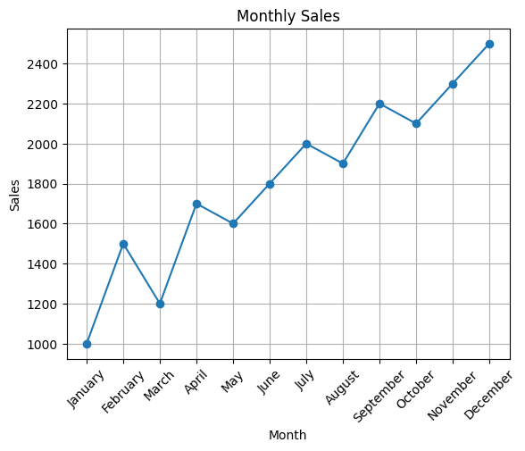

```python
plt.plot(df['Month'], df['Sales'], marker='o')
plt.title('Monthly Sales')
plt.xlabel('Month')
plt.ylabel('Sales')
plt.xticks(rotation=45)
plt.grid(True)
plt.show()
```

##### *To create a line plot of monthly sales, use matplotlib.pyplot. set the title of the plot to describe the data being visualized, label the x-axis and y-axis to provide context to the plot, rotate the x-axis labels for better readability, and add gridlines to the line plot to look better in visualization.*

## 7. Conclusion

#### Based on the analysis of the Monthly Sales dataset, the total sales across all months amount up to 21,800 units. December is the month with the highest sales figure. Conversely, January is the month with the lowest sales figure.